# Assignment 3

## Method 1: *pmap*

```r
possible_cars
```

```
##   name  mass area     power
## 1    A 10000   22  75667.97
## 2    B 65000   30 270501.67
## 3    C 38000   22 166878.53
## 4    D  5000   10  35875.22
```

```r
# Creating our sample speeds and converting from km/hr to m/s
nsample = 200
mean_speed = log(80*0.277)

speeds = rlnorm(mean=mean_speed, sd=.08*mean_speed, nsample)
summary(speeds)
```

```
##    Min. 1st Qu.  Median    Mean 3rd Qu.    Max.
##   12.57   18.76   22.24   23.09   26.29   40.12
```

```r
# Quick visualization of our distribution of speeds based on this random sample
# plot(density(speeds), ylab="Distribution of Speeds in (m/s)")

# Running each car for all speeds using pmap: runs a function for each value in a list of parameters, with other parameters set for each iteration

powerall1 = pmap(list(A = possible_cars$area, m=possible_cars$mass), autopower, V=speeds)

# Creating dataframe
powerall1 = as.data.frame(powerall1, col.names=possible_cars$name)


# Turning columns into rows to plot and table easier using pivot_longer
powerallr1 = powerall1 %>% pivot_longer(cols=everything(),
                                        names_to="car",
                                        values_to="power")

# Find mean and max powers and create table
means_pmap <- powerallr1 %>%
  group_by(car) %>%
  summarize(mean = mean(power),
            max = max(power))

means_pmap %>%
  kable(caption = "Table 1: Sample statistics for car powers using pmap method",
        col.names = c("Car", "Mean power (m/s)", "Max power (m/s)")) %>%
  kable_styling(full_width = F,
                bootstrap_options = "bordered",
                position = "center")
```

Table 1: Sample statistics for car powers using pmap method

| Car | Mean power (m/s) | Max power (m/s) |
| --- | --- | --- |
| A | 92416.09 | 314651.9 |
| B | 300372.64 | 731975.9 |
| C | 187460.37 | 479775.4 |
| D | 43550.24 | 145704.2 |

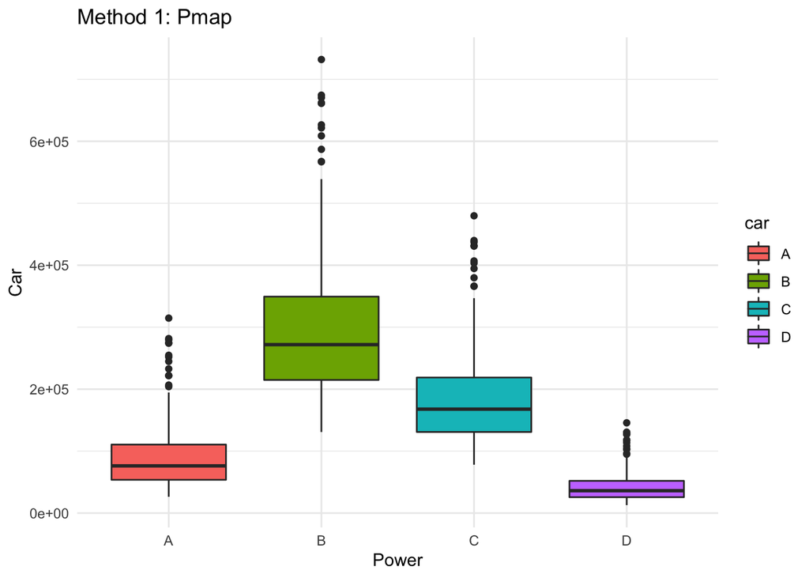

```r
# Visualization of boxplots for method 1 - pmap

method1_plot = ggplot(powerallr1, aes(car, power, fill=car)) +
  geom_boxplot() +
  ggtitle("Method 1: Pmap") +
  theme(plot.title = element_text(hjust = 0.5)) +
  labs(y = "Car", x = "Power") + theme_minimal()

method1_plot
```

**Figure 2** Boxplot displaying power consumption for each car using *pmap*.

## Method 2: Classic looping *for*

*pmap* works quickly but it is unique to R, so we will use *for* loops to compute our powers for each car as this is more common in other programming languages.

```r
possible_cars
```

```
##   name  mass area     power
## 1    A 10000   22  75667.97
## 2    B 65000   30 270501.67
## 3    C 38000   22 166878.53
## 4    D  5000   10  35875.22
```

```r
# Creating our sample speeds and converting from km/hr to m/s
nsample = 200
mean_speed = log(80*0.277)

speeds = rlnorm(mean=mean_speed, sd=.08*mean_speed, nsample)
summary(speeds)
```

```
##    Min. 1st Qu.  Median    Mean 3rd Qu.    Max.
##   12.74   17.85   21.46   22.07   25.57   41.29
```

```r
# Quick visualization of our distribution of speeds based on this random sample
# plot(density(speeds), ylab="Distribution of Speeds in (m/s)")

# Running each car for all speeds using a for loop that cycles through
# Creating dataframe
powerall2 = as.data.frame(matrix(nrow=length(speeds),
                                 ncol=nrow(possible_cars)))


# Running *for* loop using our data from possible_cars
for (i in 1:nrow(possible_cars)) {
  powerall2[,i] = autopower(A=possible_cars$area[i],
                            m=possible_cars$mass[i],
                            V=speeds)
}

# Add column names
colnames(powerall2)=possible_cars$name


# Turning columns into rows for plotting and table
powerallr2 = powerall2 %>% pivot_longer(cols=everything(),
                                        names_to="car",
                                        values_to="power")

# Find mean and max powers and create table
means_pmap <- powerallr2 %>%
  group_by(car) %>%
  summarize(mean = mean(power),
            max = max(power))

means_pmap %>%
  kable(caption = "Table 2: Sample statistics for car powers using for loop method",
        col.names = c("Car", "Mean power (m/s)", "Max power (m/s)")) %>%
  kable_styling(full_width = F,
                bootstrap_options = "bordered",
                position = "center")
```

Table 2: Sample statistics for car powers using for loop method

| Car | Mean power (m/s) | Max power (m/s) |
| --- | --- | --- |
| A | 83353.51 | 339532.7 |
| B | 280282.66 | 774784.0 |
| C | 174182.86 | 509496.9 |
| D | 39362.46 | 157092.2 |

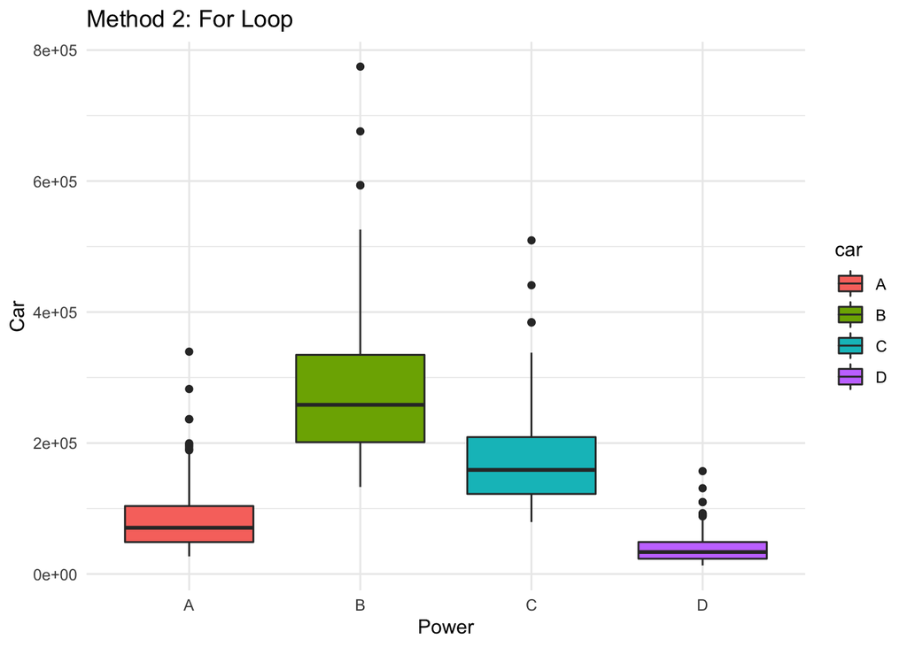

```r
# Visualization of boxplots for method 2 - for loop
method2_plot = ggplot(powerallr2, aes(car, power, fill=car)) +
  geom_boxplot() +
  ggtitle("Method 2: For Loop") +
  theme(plot.title = element_text(hjust = 0.5)) +
  labs(y = "Car", x = "Power") + theme_minimal()

method2_plot
```

**Figure 3** Boxplot displaying power consumption for each car using *for* loop.

## Both Methods Comparison

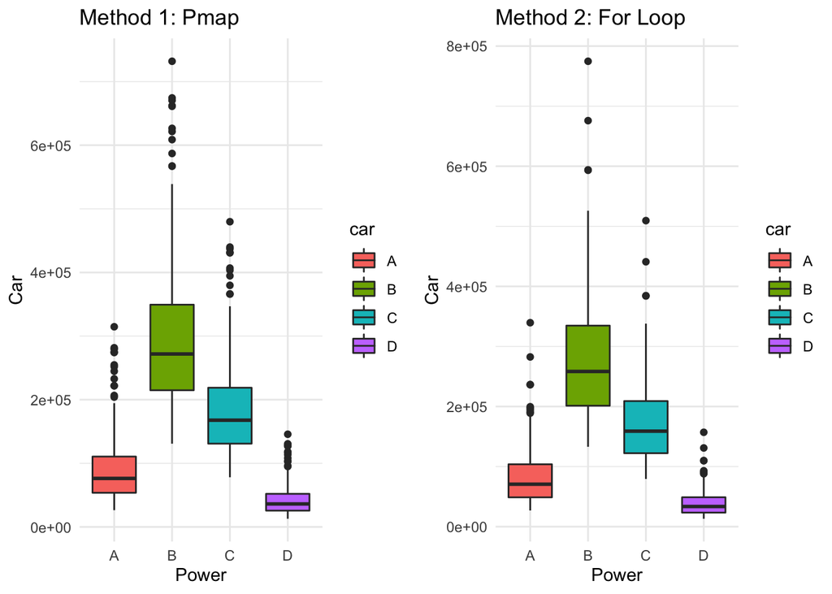

```r
# Combining the two boxplots (pmap and for loop methods) for comparison
ggarrange(method1_plot, method2_plot, nrow=1)
```

**Figure 4** Comparison of method 1 and method 2. As we used a random number generator for our samples, the power averages and ranges are different, however, the trends are the same in each scenario between car A, B, C, and D.